# Tutorial CH5

Ryan Huang

8/10/2019

```r
library(rstan)
library(rethinking)
library(tidyverse)
library(gridExtra)
```

# 1 CH5 The Many Variables

In this chapter, we will learn about how to use multiple regression using Stan.

There are two cases when we add more predictors in a regression model, continuous variables or categorical variables. In this chapter we will learn about how to treat them efficiently in stan.

Also, when we have more than one predictors in our model, it’s more complicated to interpreat the posterior result. We will learn about different plots to help us understand our posterior.

## 1.1 CH5.1 Continuous Variable

Let’s start by adding continuous variables. Following our textbook, we use the `WaffleDivorce` data. We are going to investigate the relationship between marriage age, marriage rate, and divorce rate.

### 1.1.1 Data: WaffleDivorce

We first standardize our variables.

*Noted that the output of scale is a matrix(dim=n,1), add [,1] to convert it to vector(dim=n)*

```r
data(WaffleDivorce)
div = WaffleDivorce
div = div %>%
  mutate(MedianAgeMarriage_z = scale(div$MedianAgeMarriage)[,1],
         Divorce_z = scale(div$Divorce)[,1],
         Marriage_z = scale(div$Marriage)[,1])
```

### 1.1.2 Model

We can start to write down our models. The first two models are just simple LR model. The last one is what we want. 寫模型的時候我們直接從model 3開始再把它刪成model 1, model 2就可以囉 * model 1: divorce rate = `alpha + beta * median age of marriage` * model 2: divorce rate = `alpha + beta * marriage rate` * model 3: divorce rate = `alpha + beta_1 * marriage rate + beta_2 * median age of marriage`

#### 1.1.2.1 model 5.1

divorce rate = `alpha + beta * median age of marriage`

```r
m5.1 = "
data {
    int N;
    vector[N] median_age_z;
    vector[N] divorce_z;
}
parameters {
    real alpha;
    real beta_A;
    real sigma;
}
model {
    // model
    vector[N] mu = alpha + beta_A * median_age_z;
    divorce_z ~ normal(mu, sigma);

    // prior
    alpha ~ normal(0, 0.2);
    beta_A ~ normal(0, 0.5);
    sigma ~ exponential(1);
}
"
dat5.1 = list(N = nrow(div), median_age_z = div$MedianAgeMarriage_z, divorce_z = div$Divorce_z)
fit5.1 = stan(model_code = m5.1,
              data = dat5.1,
              iter = 2000,
              chains = 2,
              cores = 2)
```

#### 1.1.2.2 model 5.2

divorce rate = `alpha + beta * marriage rate`

```r
m5.2 = "
data {
    int N;
    vector[N] marriage_z;
    vector[N] divorce_z;
}
parameters {
    real alpha;
    real beta_M;
    real<lower=0> sigma;
}
model {
    // model
    vector[N] mu = alpha + beta_M * marriage_z;
    divorce_z ~ normal(mu, sigma);

    // prior
    alpha ~ normal(0, 0.2);
    beta_M ~ normal(0, 0.5);
    sigma ~ exponential(1);
}
"
dat5.2 = list(N = nrow(div), marriage_z = div$Marriage_z, divorce_z = div$Divorce_z)
fit5.2 = stan(model_code = m5.2,
              data = dat5.2,
              iter = 2000,
              chains = 2,
              cores = 2)
```

#### 1.1.2.3 model 5.3

divorce rate = `alpha + beta_1 * marriage rate + beta_2 * median age of marriage`

```r
m5.3 = "
data {
    int N;
    vector[N] median_age_z;
    vector[N] marriage_z;
    vector[N] divorce;
    vector[N] counterfactual_A;
    vector[N] counterfactual_M;
}
parameters {
    real alpha;
    real beta_A;
    real beta_M;
    real sigma;
}
model {
    // model
    vector[N] mu = alpha + beta_A * median_age_z + beta_M * marriage_z;
    divorce ~ normal(mu, sigma);

    // prior
    alpha ~ normal(0, 0.2);
    beta_M ~ normal(0, 0.5);
    beta_A ~ normal(0, 0.5);
    sigma ~ exponential(1);
}
generated quantities {
    // counterfactual: fixed age
    vector[N] pred_mu_1;
    real pred_y_1[N];

    // counterfactual: fixed marriage
    vector[N] pred_mu_2;
    real pred_y_2[N];

    // backtest
    vector[N] pred_mu_3;
    real pred_y_3[N];

    // counterfactual: fixed age
    pred_mu_1 = alpha + beta_A * 0 + beta_M * counterfactual_M;
    pred_y_1 = normal_rng(pred_mu_1, sigma);

    // counterfactual: fixed marriage
    pred_mu_2 = alpha + beta_A * counterfactual_A + beta_M * 0;
    pred_y_2 = normal_rng(pred_mu_2, sigma);

    // backtest
    pred_mu_3 = alpha + beta_A * median_age_z + beta_M * marriage_z;
    pred_y_3 = normal_rng(pred_mu_3, sigma);
}
"
dat5.3 = list(N = nrow(div),
              median_age_z = div$MedianAgeMarriage_z,
              marriage_z = div$Marriage_z,
              divorce = div$Divorce_z,
              counterfactual_A = seq(-3, 3, length.out = 50),
              counterfactual_M = seq(-3, 3, length.out = 50))
fit5.3 = stan(model_code = m5.3,
              data = dat5.3,
              iter = 2000,
              cores = 2,
              chains = 2)
```

### 1.1.3 Posterior Interpretation

#### 1.1.3.1 Predictor residual plots

The logic: Use all other `X`s to *regress* on one `X`.

The `residual` of this model can be interpretated as the effect of this one `X`, while all the other `X`s are *controlled*.

Then we use this `residual` to *regress* on y.

We can think of this plot as displaying the linear relationship between `Y(divorce)` and `X(marriage)`, having statistically “controlled” for all the other `X(age)`.

1. Regress predictor on other predictors
2. Compute predictor residuals
3. Regress Y on residuals

```r
model = "
data {
    int N;
    vector[N] X;
    vector[N] Y;
}

parameters {
    real alpha;
    real beta;
    real sigma;
}

model {
    vector[N] mu = alpha + beta * X;
    Y ~ normal(mu, sigma);
  alpha ~ normal(0, 0.2);
    beta ~ normal(0, .5);
    sigma ~ exponential(1);
}

generated quantities {
    vector[N] res;
    vector[N] mu;
    mu = alpha + beta * X;
    res = Y - mu;
}
"
dat.resM = list(N = nrow(div),
                X = div$MedianAgeMarriage_z,
                Y = div$Marriage_z)

dat.resA = list(N = nrow(div),
                X = div$Marriage_z,
                Y = div$MedianAgeMarriage_z)


fit.resM = stan(model_code = model, data = dat.resM, cores = 2, chains = 2)
fit.resA = stan(model_code = model, data = dat.resA, cores = 2, chains = 2)
```

output

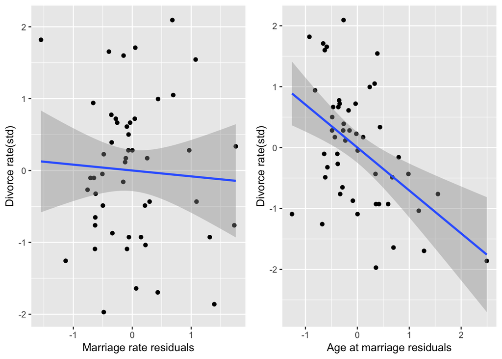

```r
resM = fit.resM %>% as.data.frame() %>% select(contains("res")) %>% apply(., 2, mean)
resA = fit.resA %>% as.data.frame() %>% select(contains("res")) %>% apply(., 2, mean)

plt.resM =
  ggplot() +
  geom_point(aes(resM, div$Divorce_z)) +
  geom_smooth(aes(resM, div$Divorce_z), method = "lm") +
  labs(x="Marriage rate residuals",
       y="Divorce rate(std)")

plt.resA =
  ggplot() +
  geom_point(aes(resA, div$Divorce_z)) +
  geom_smooth(aes(resA, div$Divorce_z), method = "lm") +
  labs(x="Age at marriage residuals",
       y="Divorce rate(std)")

grid.arrange(plt.resM, plt.resA, nrow=1)
```

Problem: Complicated idea and process

#### 1.1.3.2 Counterfactual plots

Counterfactual is similar to *what-if* analysis.

Or more intuatively, we are wondering how X2 will impact Y if we set X1 as a constant.

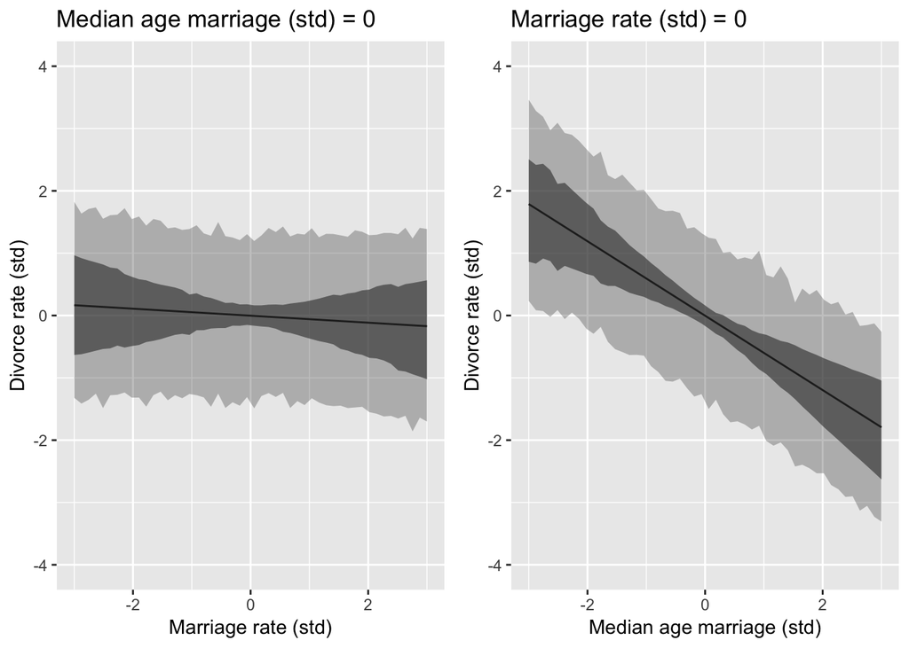

```r
post5.3 = as.data.frame(fit5.3)

# counterfactual: fixed age
pred_mu_1 = post5.3 %>% select(contains("pred_mu_1"))
pred_y_1 = post5.3 %>% select(contains("pred_y_1"))
CF.A = data.frame(
  x = seq(-3, 3, length.out = 50),
  pred = pred_mu_1 %>% apply(., 2, mean),
  CI_lower = pred_mu_1 %>% apply(., 2, HPDI) %>% .[1,],
  CI_upper = pred_mu_1 %>% apply(., 2, HPDI) %>% .[2,],
  PI_lower = pred_y_1 %>% apply(., 2, HPDI) %>% .[1,],
  PI_upper = pred_y_1 %>% apply(., 2, HPDI) %>% .[2,]
)

p_CF.A = CF.A%>%
  ggplot() +
  geom_line(aes(x, pred)) +
  geom_ribbon(aes(x, ymin=CI_lower, ymax=CI_upper), alpha=.6) +
  geom_ribbon(aes(x, ymin=PI_lower, ymax=PI_upper), alpha=.3) +
  ylim(-4,4) +
  labs(x="Marriage rate (std)",
       y="Divorce rate (std)",
       title = "Median age marriage (std) = 0")

# counterfactual: fixed marriage
pred_mu_2 = post5.3 %>% select(contains("pred_mu_2"))
pred_y_2 = post5.3 %>% select(contains("pred_y_2"))


CF.M = data.frame(
  x = seq(-3, 3, length.out = 50),
  pred = pred_mu_2 %>% apply(., 2, mean),
  CI_lower = pred_mu_2 %>% apply(., 2, HPDI) %>% .[1,],
  CI_upper = pred_mu_2 %>% apply(., 2, HPDI) %>% .[2,],
  PI_lower = pred_y_2 %>% apply(., 2, HPDI) %>% .[1,],
  PI_upper = pred_y_2 %>% apply(., 2, HPDI) %>% .[2,]
)

p_CF.M = CF.M%>%
  ggplot() +
  geom_line(aes(x, pred)) +
  geom_ribbon(aes(x, ymin=CI_lower, ymax=CI_upper), alpha=.6) +
  geom_ribbon(aes(x, ymin=PI_lower, ymax=PI_upper), alpha=.3) +
  ylim(-4,4) +
  labs(x="Median age marriage (std)",
       y="Divorce rate (std)",
       title = "Marriage rate (std) = 0")

grid.arrange(p_CF.A, p_CF.M, nrow=1)
```

Problem: The plot shows the “prediction” of any combination of `X`s, however, some of them are impossible in the real world.

#### 1.1.3.3 Posterior prediction plots

Directly plot the predictions of real data (back test). Since we have more than 1 predictors, we can’t easily compare the the prediction and true values using a X-Y plot.

Alternatively, we will plot pred_y against true_y. The points closer to the diagonal line are better predictions.

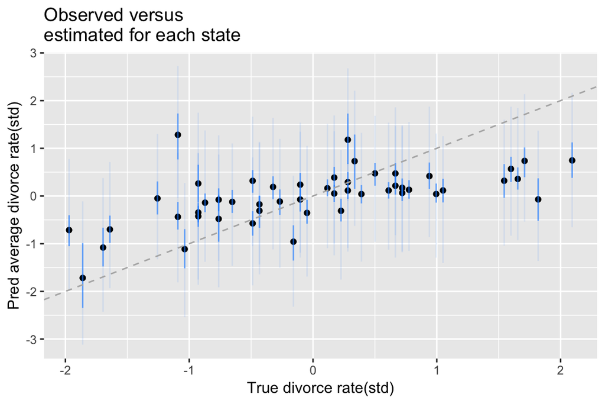

```r
pred_mu_3 = post5.3 %>% select(contains("pred_mu_3"))
pred_y_3 = post5.3 %>% select(contains("pred_y_3"))

back.test = data.frame(
  pred_y = pred_mu_3 %>% apply(., 2, mean),
  true_y = div$Divorce_z,
  CI_lower = pred_mu_3 %>% apply(., 2, HPDI) %>% .[1,],
  CI_upper = pred_mu_3 %>% apply(., 2, HPDI) %>% .[2,],
  PI_lower = pred_y_3 %>% apply(., 2, HPDI) %>% .[1,],
  PI_upper = pred_y_3 %>% apply(., 2, HPDI) %>% .[2,]
)

back.test %>%
  ggplot() +
  geom_point(aes(true_y, pred_y)) +
  geom_segment(aes(x=true_y, xend=true_y,
               y=CI_lower, yend=CI_upper), alpha=.6, color="dodgerblue") +
  geom_segment(aes(x=true_y, xend=true_y,
               y=PI_lower, yend=PI_upper), alpha=.1, color="dodgerblue") +
  geom_abline(intercept = 0, slope = 1,
              linetype = 'dashed', color = 'gray70') +
  labs(x = "True divorce rate(std)",
       y = 'Pred average divorce rate(std)',
       title = 'Observed versus\nestimated for each state')
```

#### 1.1.3.4 Coefficient Table

Another technique is to just compare the coefficients of differnet models

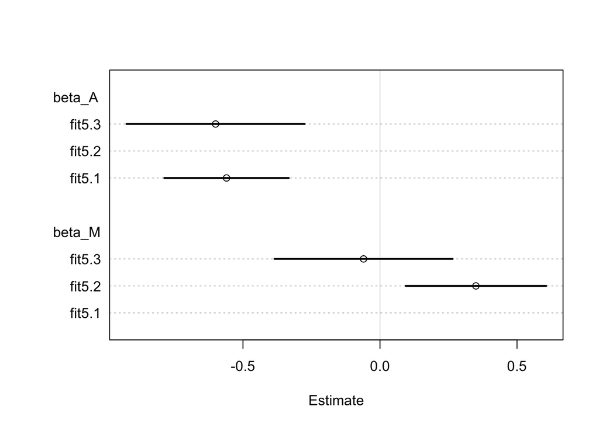

```r
plot(coeftab(fit5.1 , fit5.2 , fit5.3), pars=c("beta_A","beta_M"))
```

## 1.2 CH5.2 Categorical Variable

Instead of using `dummy coding`, we use `index coding` to avoid the uncertainty problem. (Under dummy coding, the reference level has fewer parameters, see rethinking ver2 p.166)

### 1.2.1 Binary Categories

Height Example:

- Dummy coding: height = alpha + gender + beta * weight
- index coding: height = alpha[gender] + beta * weight

#### 1.2.1.1 Data

Load the `Howell1` data and convert `male` to integers.

```r
data(Howell1)
HIGH = Howell1
HIGH$male = HIGH$male %>% as.integer() # r index is 1 based
```

#### 1.2.1.2 Model

There are some tricky parts in setting the model. 1. the categorical variable must be declared as array of `int` (from 1 to number of levels). 2. `alpha` can be set as either vector[L] or real array[L] where `L` denotes how many levels we have. 3. use the categorical variable as the index 4. use for loop

```r
m5.4 = "
data {
    int N;
    int L; // number of levels

    vector[N] weight;
    int gender[N]; // must set to be int, not vector
    vector[N] height;
}

parameters {
    real alpha[L]; // 2 different intercept
    real beta;
    real sigma;
}

model {
    // model
    vector[N] mu;

  // for loop
    for (i in 1:N){
        mu[i] = alpha[gender[i]] + beta * weight[i];
    }
    height ~ normal(mu, sigma);

    // prior
    for (i in 1:L){
        alpha[i] ~ normal(178, 20);
    }

    beta ~ lognormal(0, 1);
    sigma ~ exponential(1);
}

generated quantities {
    vector[N] pred_mu;
    real pred_y[N];

    for (i in 1:N){
        pred_mu[i] = alpha[gender[i]] + beta * weight[i];
    }

    pred_y = normal_rng(pred_mu, sigma);
}
"
dat5.4 = list(N = nrow(HIGH),
              L = HIGH$male %>% unique() %>% length(),
              weight = HIGH$weight,
              gender = HIGH$male+1,
              height = HIGH$height)
fit5.4 = stan(model_code = m5.4,
              data = dat5.4,
              cores = 2,
              chains = 2,
              iter = 2000)
```

```r
print(fit5.4, pars=c("alpha", "beta", "sigma"))
```

```
## Inference for Stan model: bbc498aac391b8997cca6392da32e830.
## 2 chains, each with iter=2000; warmup=1000; thin=1;
## post-warmup draws per chain=1000, total post-warmup draws=2000.
##
##           mean se_mean   sd  2.5%   25%   50%   75% 97.5% n_eff Rhat
## alpha[1] 76.17    0.04 1.05 74.03 75.45 76.22 76.87 78.17   762    1
## alpha[2] 75.85    0.04 1.17 73.59 75.07 75.83 76.62 78.13   697    1
## beta      1.75    0.00 0.03  1.70  1.73  1.75  1.77  1.80   690    1
## sigma     9.31    0.01 0.28  8.77  9.11  9.30  9.50  9.86  1091    1
##
## Samples were drawn using NUTS(diag_e) at Thu Aug 15 14:04:02 2019.
## For each parameter, n_eff is a crude measure of effective sample size,
## and Rhat is the potential scale reduction factor on split chains (at
## convergence, Rhat=1).
```

### 1.2.2 Many Categories

Milk Example: There are 4 different `clade`s, we want to compare them.

- Dummy coding: kcal.per.g = clade1 + clade2 + clade3 + beta * mass
- Index coding: kcal.per.g = alpha[clade] + beta * mass

#### 1.2.2.1 Data

```r
data(milk)
glimpse(milk)
```

```
## Observations: 29
## Variables: 8
## $ clade          <fct> Strepsirrhine, Strepsirrhine, Strepsirrhine, Stre…
## $ species        <fct> Eulemur fulvus, E macaco, E mongoz, E rubriventer…
## $ kcal.per.g     <dbl> 0.49, 0.51, 0.46, 0.48, 0.60, 0.47, 0.56, 0.89, 0…
## $ perc.fat       <dbl> 16.60, 19.27, 14.11, 14.91, 27.28, 21.22, 29.66, …
## $ perc.protein   <dbl> 15.42, 16.91, 16.85, 13.18, 19.50, 23.58, 23.46, …
## $ perc.lactose   <dbl> 67.98, 63.82, 69.04, 71.91, 53.22, 55.20, 46.88, …
## $ mass           <dbl> 1.95, 2.09, 2.51, 1.62, 2.19, 5.25, 5.37, 2.51, 0…
## $ neocortex.perc <dbl> 55.16, NA, NA, NA, NA, 64.54, 64.54, 67.64, NA, 6…
```

#### 1.2.2.2 Model

When we have many categories, the advantage of using index coding is more obvious. We don’t need to create extra columns for dummy variables, and the code are almost the same as the binary category model.

```r
m5.5 = "
data {
    int N;
    int L; // number of levels
    vector[N] mass;
    int clade[N];
    vector[N] kcal;
}
parameters {
    real alpha[L]; // 2 different intercept
    real beta;
    real sigma;
}
model {
    // model
    vector[N] mu;
    for (i in 1:N){
        mu[i] = alpha[clade[i]] + beta * mass[i];
    }
    kcal ~ normal(mu, sigma);

    // prior
    for (i in 1:L){
        alpha[i] ~ normal(0, 1);
    }

    beta ~ lognormal(0, 1.5);
    sigma ~ exponential(1);
}
generated quantities {
    vector[N] pred_mu;
    real pred_y[N];

    for (i in 1:N){
        pred_mu[i] = alpha[clade[i]] + beta * mass[i];
    }

    pred_y = normal_rng(pred_mu, sigma);
}
"
dat5.5 = list(
  N = nrow(milk),
  L = milk$clade %>% unique() %>% length(),
  mass = milk$mass %>% scale %>% .[,1],
  clade = milk$clade %>% as.integer,
  kcal = milk$kcal.per.g
)
fit5.5 = stan(model_code = m5.5,
              data = dat5.5,
              iter = 3000,
              warmup = 2000,
              chains = 4,
              cores = 4)
```

result

```r
summary(fit5.5, pars=c("alpha", "beta", "sigma"), depth = 2, prob=.95)$summary
```

```
##                mean      se_mean         sd        95%    n_eff      Rhat
## alpha[1] 0.50390999 0.0010844136 0.05103243 0.58705067 2214.637 0.9996208
## alpha[2] 0.73433324 0.0008787090 0.04601671 0.81005426 2742.465 1.0001479
## alpha[3] 0.80007441 0.0010889967 0.05762880 0.89282482 2800.439 1.0021304
## alpha[4] 0.52519707 0.0012612446 0.06154682 0.62590122 2381.291 0.9998246
## beta     0.03834927 0.0005692973 0.02247174 0.08067405 1558.099 1.0018796
## sigma    0.13452661 0.0004531320 0.02080004 0.17141499 2107.070 1.0008255
```